# hmwave_demo_0

## History matching waves demonstration

History matching process (for each separate output):

generate initial design  
generate a target point  
generate a uniform sample (for visulasation and calculating space sizes)

for each output:  
- run the model at the design points  
- run the model at the target point  
- fit a dicekriging km() to each output  
- calculate the implausibility of each point in the uniform sample  
- calculate the implausibility of each point in the augmented lhs  
- return the model fit and some fit statistics, both sets of implausibility calculations, and the new design

```r
library(lhs)
library(DiceKriging)
source('https://raw.githubusercontent.com/dougmcneall/packages-git/5f79ffe749f25c6fc39f4f7925e1538d36b7caf1/emtools.R')
source('https://raw.githubusercontent.com/dougmcneall/packages-git/5f79ffe749f25c6fc39f4f7925e1538d36b7caf1/imptools.R')
source('https://raw.githubusercontent.com/dougmcneall/packages-git/5f79ffe749f25c6fc39f4f7925e1538d36b7caf1/vistools.R')

source('hmwave_demo_0.fun.R')
```

## Run the model a large number of times and visualise the output here.

### initial design

Set up an initial design, sampling sparsely from the input domain (as if the model was expensive to run).  
Experiment with n (initial design points), n.app (number of points to augment the design with in each wave), and uncertainty budget.

```r
n = 10 # number of initial design points
k = 4  # number of model inputs
d = 3  # number of model outputs

# simplest method is to choose a subset of the discovered NROY
# points to append to the design

n.app = 10 # number of points to append

X = maximinLHS(n, k = k,dup = 2)
colnames(X) <- c('x1', 'x2', 'x3', 'x4')

X.target = matrix(runif(4), nrow = 1)

# run the model outside of the function
#Y = run.model(X)
#Y.target = run.model(X.target)


Y.raw = run.model(X)
# Mean and standard deviation of the raw output

print(c('Output mean = ', c(round(apply(Y.raw ,2, mean),2))))

print(c('Output SD = ', round(apply(Y.raw,2,sd),2)))

Y.target.raw = run.model(X.target)

print(c('Output target = ', round(Y.target.raw),2))


Y.all.norm = normalize(rbind(Y.raw, Y.target.raw))
Y = Y.all.norm[1:n, ]
Y.target = matrix(Y.all.norm[n+1, ], nrow = 1)

print(c('Normalised output mean = ', round(apply(Y.all.norm ,2, mean),2)))
print(c('Normalised output SD = ', round(apply(Y.all.norm,2,sd),2)))
print(c('Output target = ', round(Y.target,2)))


# The standard deviation of the model output is approximately [5,5,1] and the
# mean is around [12,8,2]

# With a small number of design points, the target is often at one of the margins of the normalised space
```

[output not shown]

### Model output

The model input is 4 dimensional and output is 3 dimensional, which is hard to visualise. This is what happens when you can run the model as many times as you like, and vary the inputs one-at-a-time.

```r
n.sens = 21
X.oaat = oaat.design(X, n.sens, hold = X.target)
Y.oaat = run.model(X.oaat)
linecols = c('black', 'red', 'blue')


ylim = c(0,1)
xlim = c(0,1)

par(mfrow = c(2,2), mar = c(4,4,2,1), oma = c(0.5,0.5, 3, 0.5))
ndat = ncol(Y.oaat)
d = ncol(X.oaat)
for(i in 1:d){
  ix = seq(from = ((i*n.sens) - (n.sens-1)), to =  (i*n.sens), by = 1)
  plot(X.oaat[ix,i], Y.oaat[ix,2],
       type = 'n',
       ylab= 'Y', axes = FALSE,
       main = '',
       xlab = paste0('X',i),
       xlim = c(0,1), ylim = c(0,20))

  for(j in 1:ndat){

    y.oaat = Y.oaat[ix,j]
    lines(X.oaat[ix,i],y.oaat, col = linecols[j], lwd = 2)
  }
  axis(1, col = 'grey', col.axis = 'grey', las = 1, title = 'X')
  axis(2, col = 'grey', col.axis = 'grey', las = 1)
 # mtext(3, text = colnames(lhs)[i], line = 0.2, cex = 0.7)
}
reset()
```

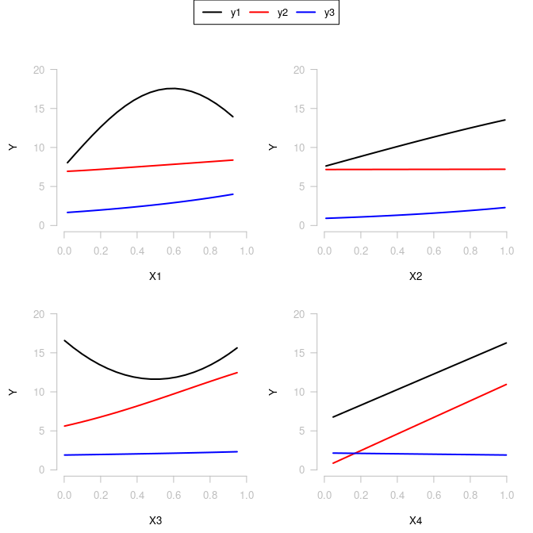

```r
legend('top',
       legend = colnames(Y),
       col = linecols,
       cex = 0.8,
       lwd = 2,
       horiz = TRUE)
```

```r
#dev.off()
```

```r
# Assume the entire uncertainty budget is in the observational uncertainty initially
obs.sd.list = list(0.013,0.013,0.013)
disc.list = list(0,0,0)
disc.sd.list = list(0, 0, 0)

thres = 3   # implausibility threshold

mins.aug = rep(0,4)
maxes.aug = rep(1,4)

# Improvements to the above function from Andrianakis et al. (2015)
# 1) Reduce the range the emulator is fit over, as the waves continue.
# 2) Sample candidate design points from NEAR the existing NROY design points.
```

## Do the History matching in 6 waves

### Visualize the results

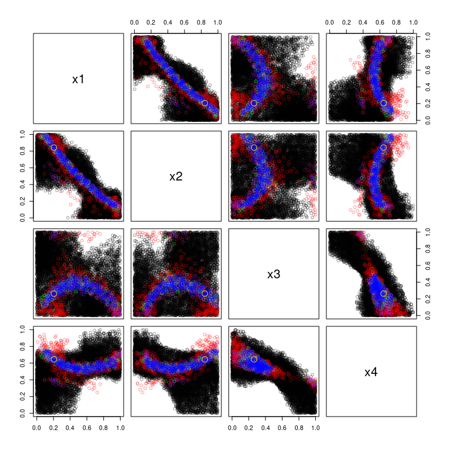

```r
all.nroy = rbind(wave1$X.nroy, wave2$X.nroy, wave3$X.nroy, wave4$X.nroy, wave5$X.nroy, wave6$X.nroy, X.target)

transp = 100

cols = c(rep(makeTransparent('black',transp),nrow(wave1$X.nroy)),
         rep(makeTransparent('red',transp),nrow(wave2$X.nroy)),
         rep(makeTransparent('purple',transp),nrow(wave3$X.nroy)),
         rep(makeTransparent('green', transp),nrow(wave4$X.nroy)),
         rep(makeTransparent('grey', transp),nrow(wave5$X.nroy)),
         rep(makeTransparent('blue',transp),nrow(wave6$X.nroy)),
          rep('gold', 1)

)
cex = c(rep(1, nrow(all.nroy)-1), 2)

pairs(all.nroy, xlim = c(0,1), ylim = c(0,1), col = cols, cex = cex, pch = 21)
```

How much does the volume of input space reduce with each wave?  
Very often we find no real gain (or even a degradation) after the first 3 waves.

This last bit isn’t right - I think the function draws from a smaller space each time so It’s not a fair comparison. Need a function that estimates the NROY proportion from the initial space - probably using importance sampling. Check other HM papers to see how this is done.

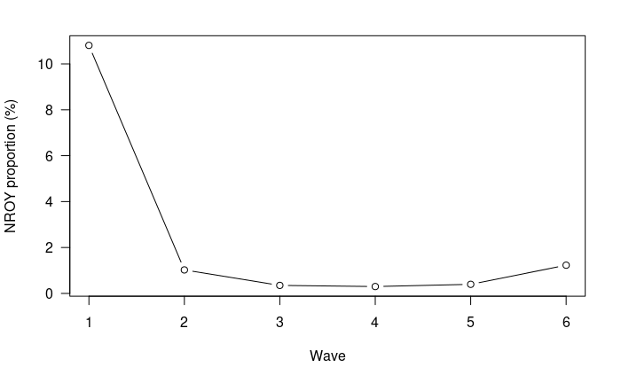

```r
waves_list = list(wave1, wave2, wave3, wave4 ,wave5, wave6)

GetNroyProp = function(waveobj){
  nrow(waveobj$X.nroy) / nrow(waveobj$X.aug)
}

wave.prop = lapply(waves_list, FUN = GetNroyProp)

par(las = 1)
plot(1:length(waves_list), c(wave.prop, recursive = TRUE) * 100, type = 'b',
     xlab = 'Wave', ylab = 'NROY proportion (%)')
```

```r
NA
NA
NA
```